# In-Class Quiz 1

Jack Sylvia

1/26/2022

“All work presented is my own. I have not communicated with or worked with anyone else on this quiz.”

Jack Sylvia

```r
library(tidyverse)
```

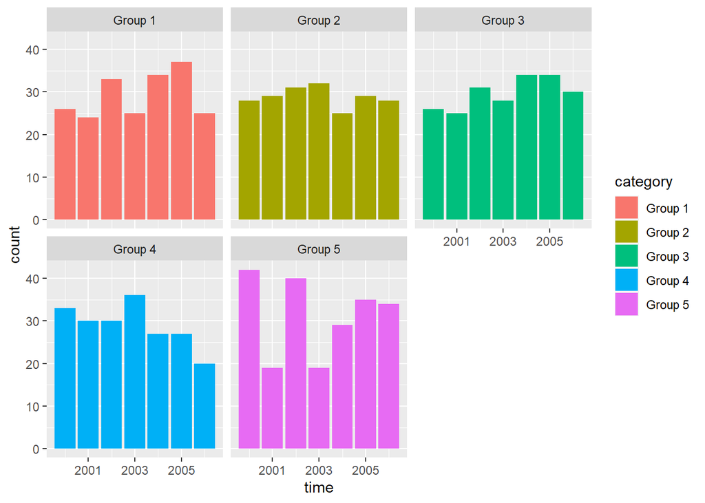

```r
category <- rep(c("Group 1", "Group 2", "Group 3", "Group 4", "Group 5"), 7)
time <- rep(c(2000, 2001, 2002, 2003, 2004, 2005, 2006), each = 5)
response <- rpois(length(category), 30)
df <- tibble(category, time, response)

ggplot(data = df, aes(x = time, y = response)) +
  geom_col(aes(fill = category)) +
  labs(y = "count") + facet_wrap(~ category)
```

3a. A diverging color scale should be used because we are looking at percent change as well as the direction of movement in cases.  
3b. We should use a sequential color scale as we are now using only concerned about cases – the higher the number of the cases the higher the intensity of the color.  
4. Compared to the first visualization at the top of the quiz, the parameter was adjuested to have the axes flipped. Also, there was an aesthetic mapping change made to have an axis read “response” instead of “count”.  
5a.

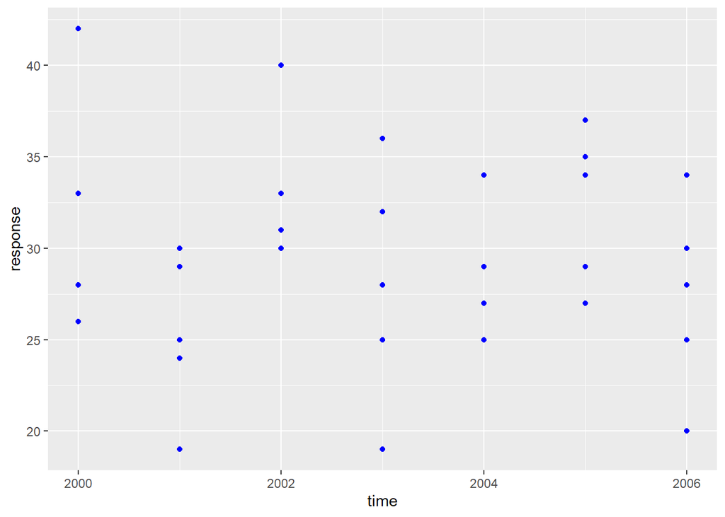

```r
ggplot(data = df, aes(x = time, y = response), colours("blue")) +
  geom_point(colour = "blue")
```

Since you are not in the ggplot parentheses making an aesthetic mapping with geom_point will not work.  
5b.

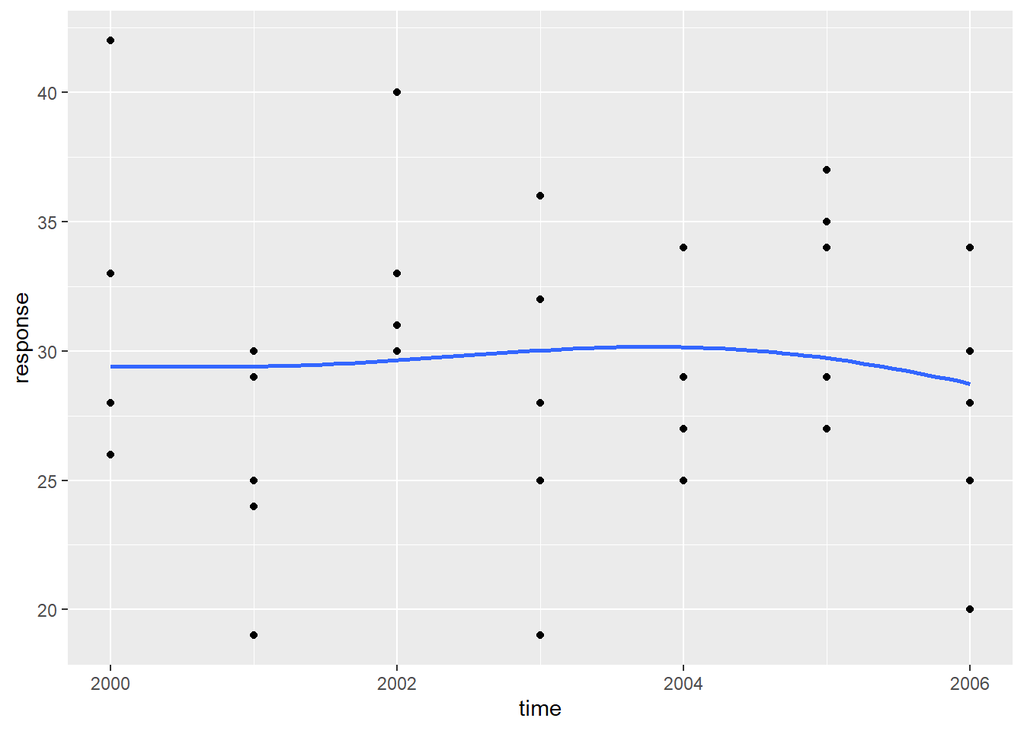

```r
ggplot(data = df, aes(x = time, y = response)) +
  geom_point() +
  geom_smooth(se = FALSE, span = 1.9)
```

Color was attached to category as aesthetic mapping. Taking that away allowed there to be just a single best fit plot.